# Predicting survival on the Titanic - Decision Tree (.78) & Random Forest (.80)

Tom Perkins

04/03/2020

## 1.Clean & Visualise

### The Data

The below kernel summarises an approach I took to the infamous Titanic challenge

A number of predictive techniques are implemented, comparing cross-validated results to submission results:

### Data set-up

First, lets load-in our dependencies :

```r
library(plyr) # means
library(dplyr) # data-cleaning
library(stringr) # data-cleaning
library(naniar) # missing data visualisation
library(ggplot2) # visualising predictors
library(rpart) # decision trees
library(rattle) # visualise decision trees
library(rpart.plot) # visualise decision trees
library(randomForest) # random forests
library(recipes) # random forests
library(caret) # model tuning
library(caTools) # cross validation
library(pROC) # ROC curves
library(RColorBrewer)
library(Hmisc)
library(kableExtra) # markdown tables
```

Then load in our train & test data-sets

```r
# Read in .csv files
train <- read.csv("train.csv")
test <- read.csv("test.csv")

# Create survived column in test set
test$Survived <- NA
# Bind test and train data to create new variables in both sets
combined <- rbind(train, test)
# Check data
str(combined)
```

### Data Cleaning

Let’s first examine which variables are missing data

```r
# Convert all blanks to NA
combined[combined==""]  <- NA
# Check our missing data situation
miss <- sapply(combined[-2], function(x) sum(is.na(x)))
```

|  | x |
| --- | --- |
| PassengerId | 0 |
| Pclass | 0 |
| Name | 0 |
| Sex | 0 |
| Age | 263 |
| SibSp | 0 |
| Parch | 0 |
| Ticket | 0 |
| Fare | 1 |
| Cabin | 1014 |
| Embarked | 2 |

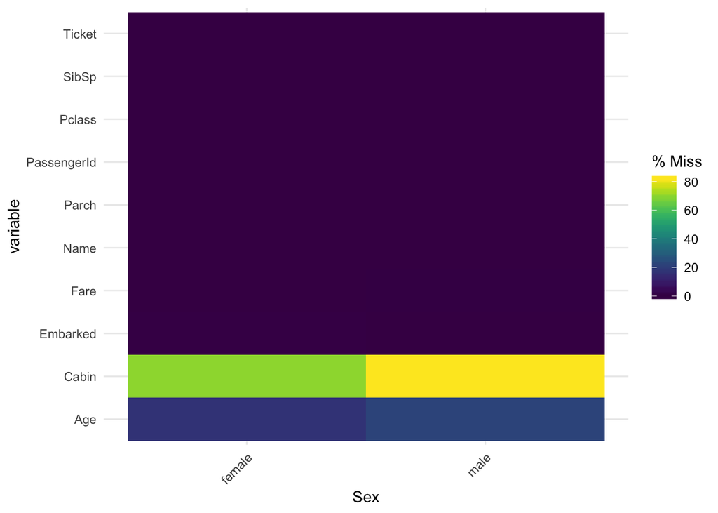

“Age” & “Cabin” are missing significant amounts of data, with a slightly higher proportion of cabin details missing for males

We can check whether missing cabin information is spread evenly across passenger “class”

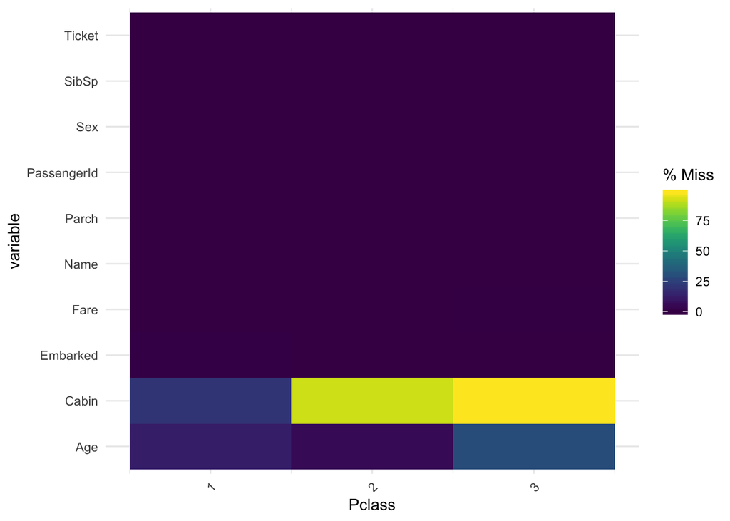

Perhaps unsuprisingly, there is more missing information in the lower classes. I’m going to presume better historical records are maintained for affluent passengers

Let’s examine missing data for Cabin x SibSp (i.e. number of siblings)

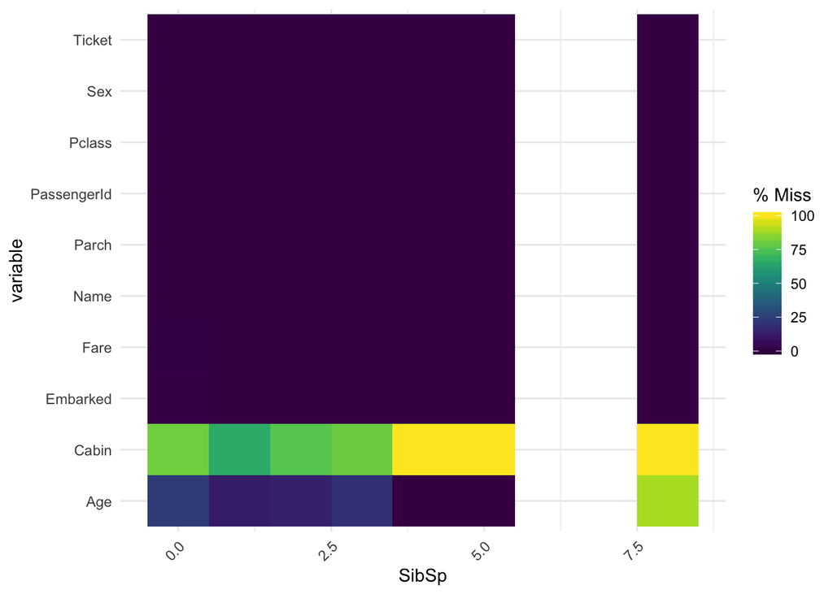

Missing data for Cabin appears to rise as SibSp rises (i.e. more siblings == more missing data). This may suggest a systematic bias in record keeping of higher-occupancy cabins.

Generally, a feature with this much missing is a lost cause, & risks significantly biasing a model. Potentially a feature could be extracted utilising cabin details for first class passengers as this data is more complete. However, I opted not to proceed further with this variable

Passenger’s age has ~ 20% missing data, & therefore is suitable for missing value imputation. Below I have fitted a decision tree to predict missing values, utilising other variables as predictors of missing values. A decision tree was Previous favored over linear regression as previous attempts were sub-optimal, producing negative age values

```r
# Use a decision tree to predict missing values
# Create DF with missing age values removed
NoMissing <- combined %>% filter(!is.na(Age))
# Create a predictive model for age
fit.missing <- rpart(Age ~ Pclass + Sex + SibSp + Parch + Fare + Embarked,
                  data = NoMissing)
# Examine the model
summary(fit.missing)
# Examine the coefficients
fit.missing
# Create 'age predicted' column from fit.missing, into initial data-set
combined <- combined %>%
  mutate(age.predicted = predict(fit.missing, .)) %>%
  # Replace NAs in combinedd$Age, with age.predicted
  mutate(Age = ifelse(is.na(Age), age.predicted, Age))
# Remove predicted age column
combined$age.predicted <- NULL
print(fit.missing)

# Replace any values below 1 with 1 to keep consistent with age-data
combined$Age[combined$Age < 1] <- 1
```

A small number of data-points were missing from port of embarkment, which have been corrected

```r
# replace missing embarked values
combined$Embarked[c(62,830)] = "S"
combined$Embarked <- factor(combined$Embarked)
```

With one missing fare value, we can safely replace this with the median without biasing our model

```r
# replace missing fare value
combined$Fare[1044] <- median(combined$Fare, na.rm = TRUE)
```

Finally, I have made some corrections to some implausible values that previous kernels have identified

```r
# Data-set errors
# The following fixes SibSp/Parch values for two passengers (Id=280 and Id=1284) according to this kernel
# because a 16 year old can’t have a 13 year old son!

combined$SibSp[combined$PassengerId == 280] = 0
combined$Parch[combined$PassengerId == 280] = 2
combined$SibSp[combined$PassengerId == 1284] = 1
combined$Parch[combined$PassengerId == 1284] = 1
```

### Data exploration and visualisation

The below section utilises density plots to visualise the relationships between various predictors of survival

#### Survival x Age

Below you can see that passengers survival status was fairly evenly distributed across the age-span of passengers, with a slightly higher density of survivors under 10 years of age

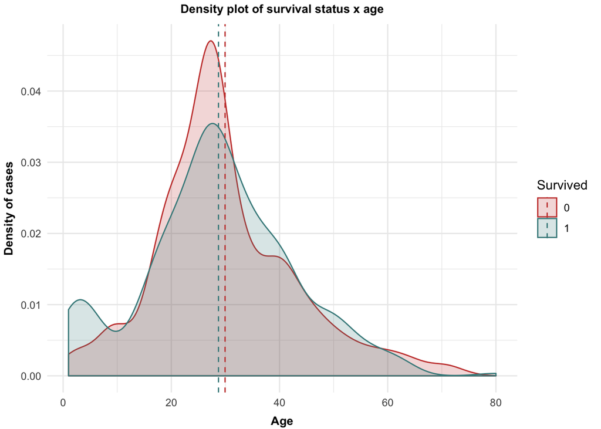

#### Sex x Survival

Using a stacked bar chart we can visualise passengers survival status x sex

Fairly clearly, (a) there were more male passengers on the titanic, & (b) survival rates were much higher for female passengers

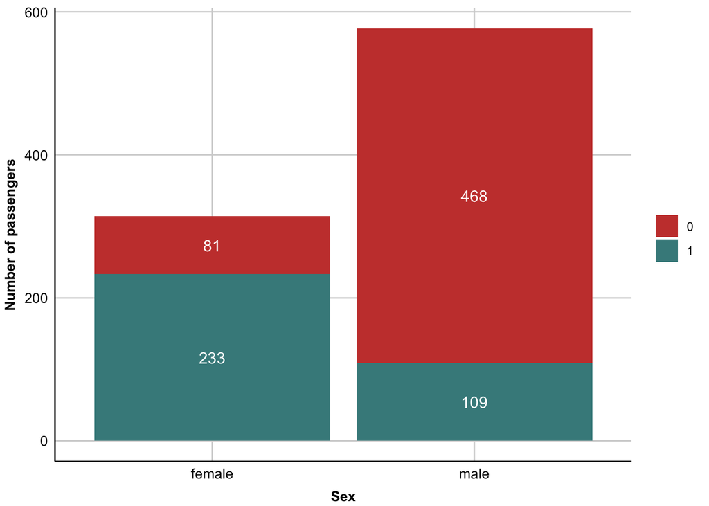

#### Sex x Age x Survival

Below are two density plots plotting passenger Age x Sex for (a) surviving passengers, & (b) non-surviving passengers

For survivors, the distribution is fairly similar for males & females, with slightly more young males surviving

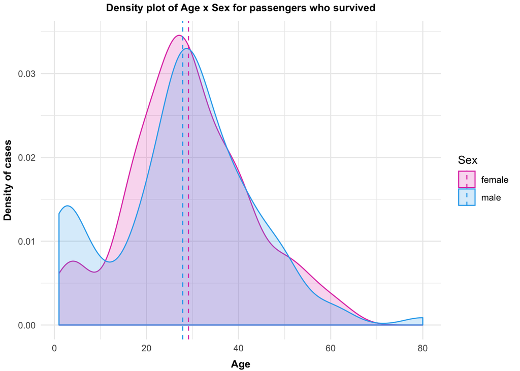

For non-survivors, the distribution of age x gender is more disparate. Proportionally more females than males under 20 years of age died, whilst over the age of 20, more males died

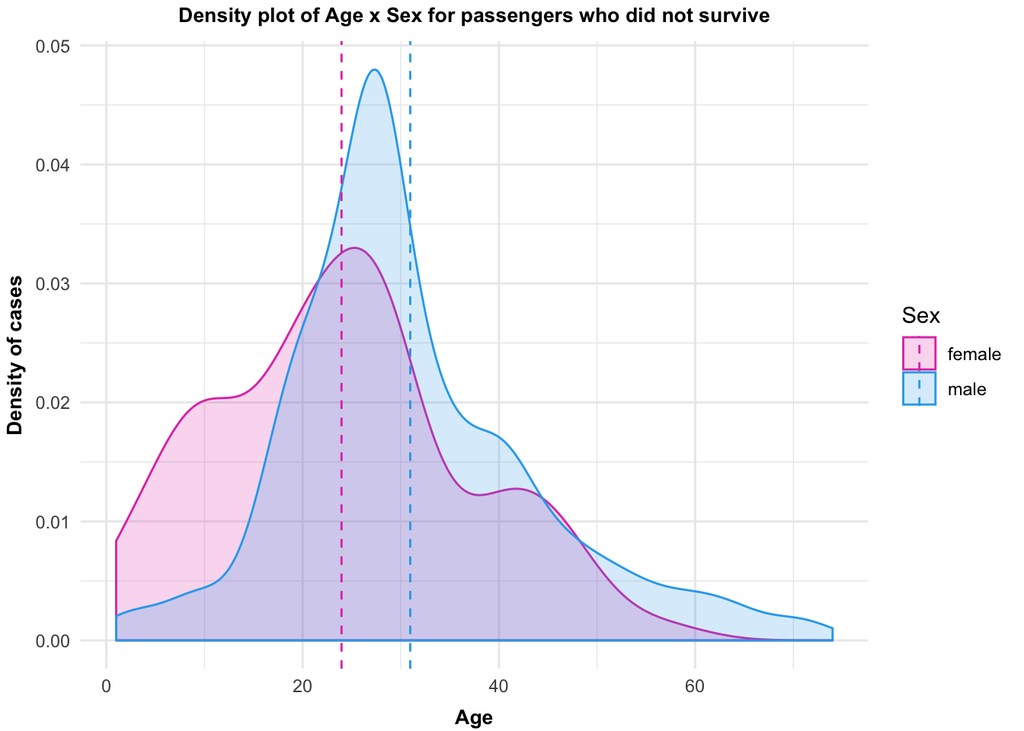

#### Class x Survival

There were three passengers classes on the titanic - 1, 2 & 3. Somewhat unsuprisingly, more passengers died in the poorer passenger classes

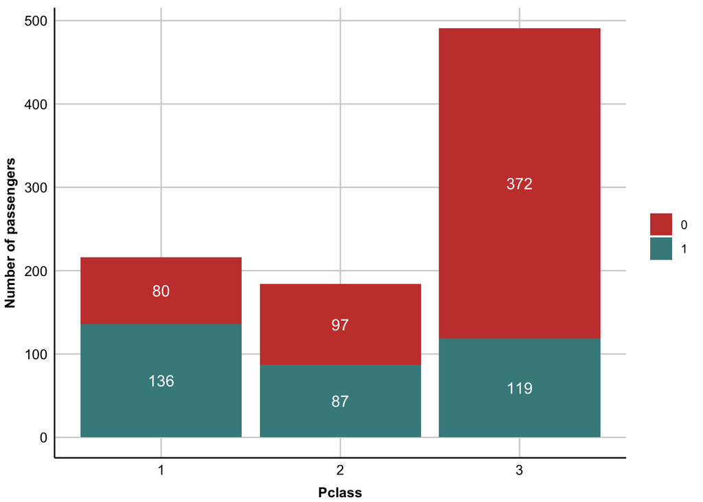

#### Class x Age x Survival

Some noteworthy differences are a higher density of surviving passengers < 10 years of age in class (2), and a higher density of non-surviving passengers > 60 in class (1)

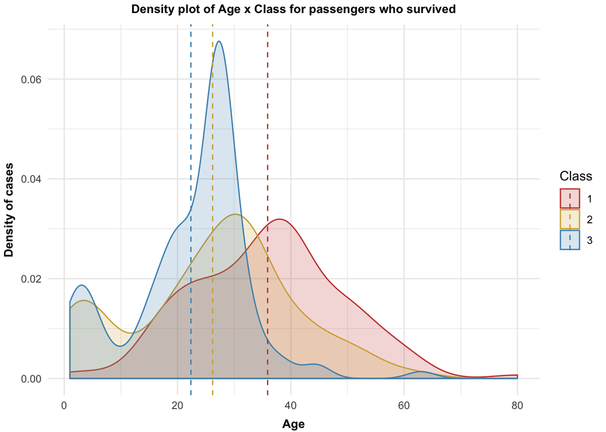

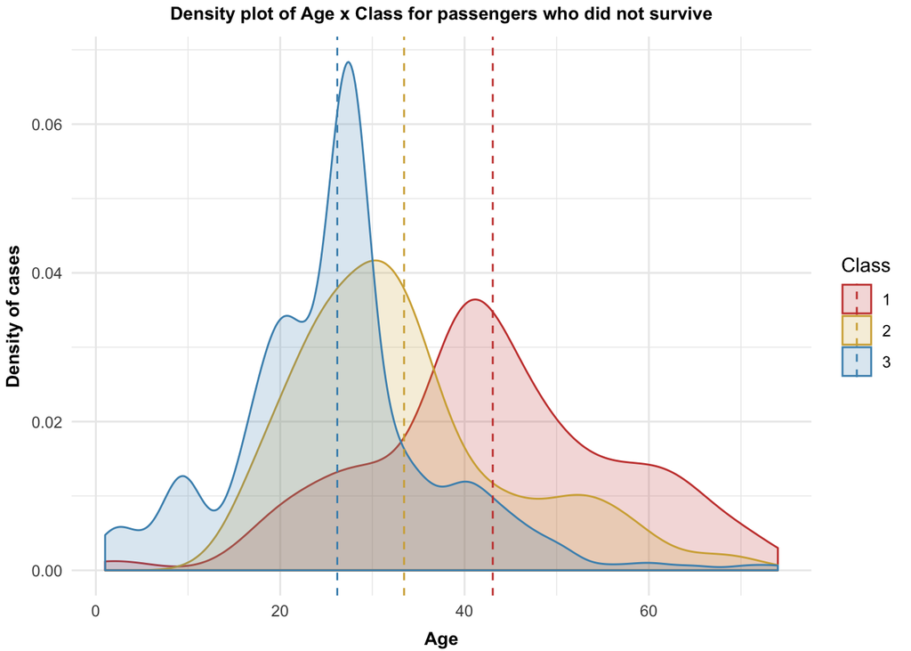

#### Embarked x Survival

Passengers boarded the Titanic from three ports of embarkment - Southampton, Cherbourg & Queenstown. The vast majority of passengers were from the first port of embarkment (Southampton).

There were more non-surviving Passengers embarking from Southampton & Queenstown, but more surviving passengers from Cherbourg. As such, port of embarkment appears related to survival probability

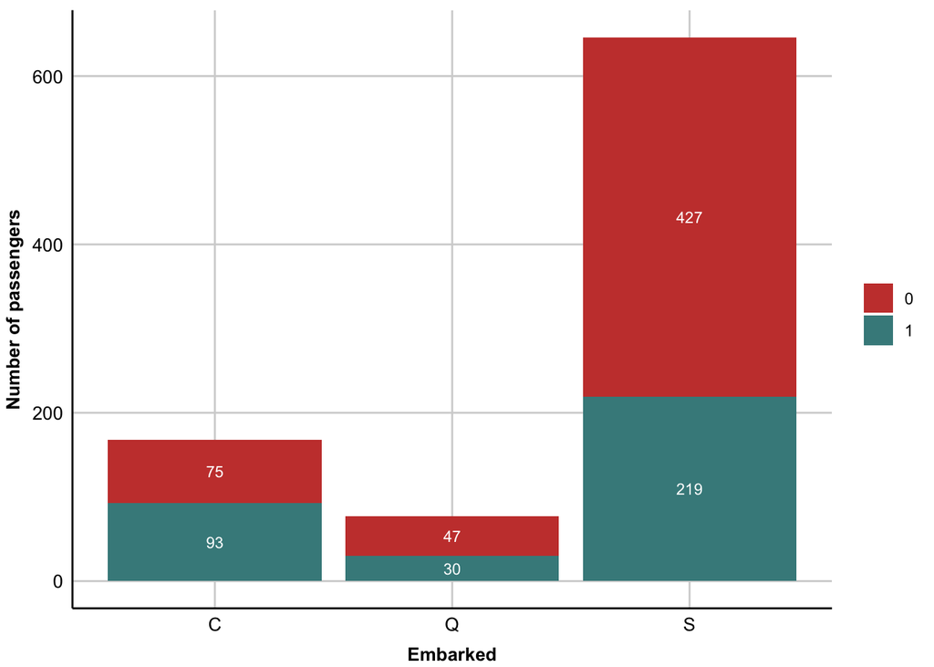

#### Embarked x Age x Survival

Density plots of port of embarkment by age show some marked differences between survivors & non-survivors

For Southampton & Cherbourg passengers, a flatter age distribution is notable for survivors compared to non-survivors. Those who survived were randomly distributed across the age spectrum, compared to deceased passengers who were more concentrated around the mean age (~ 30 for these two ports).

This pattern does not exist for Queenstown, with narrow age distributions observed for both survivors and non-survivors. In fact, the distribution for survivors from Queenstown is especially narrow, with all survivors being aged between 10 & 40. Non-survivors from Queenstown cover the entire age spectrum from infants through to the elderly

Why this is the case is unclear. With only 77 passengers embarking from Queenstown, perhaps certain travel parties survived or died together. The surviving parties potentially having no dependents (i.e. very young children or very elderly relatives). In any case, it shows port of embarkment is potentially an important predictor

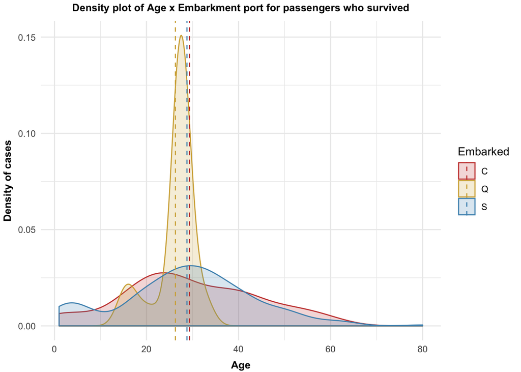

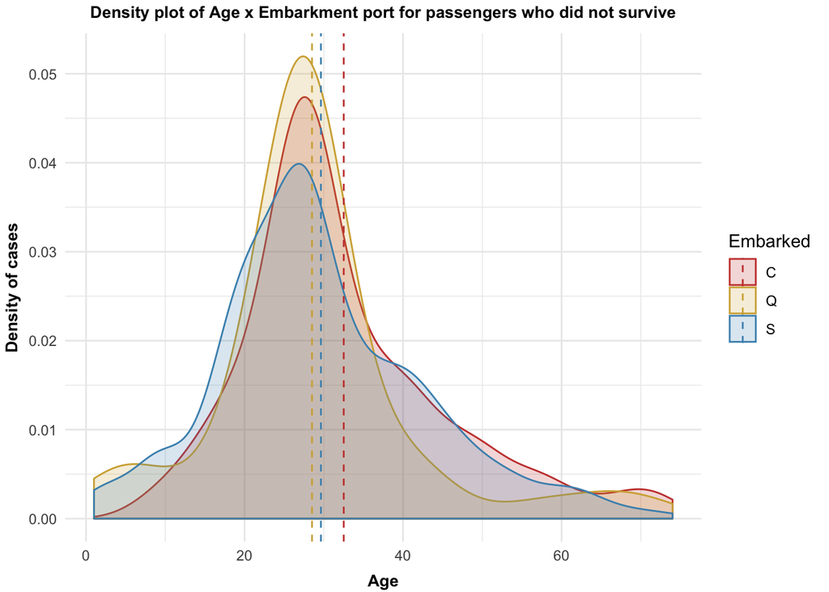

### Feature Extraction

#### Title

An obvious, and routinely extracted feature from the data-set is passengers title. It can be fairly simply derived via regex

```r
# change to character
combined$Name <- as.character(combined$Name)

# Extract title from passenger name
combined$Title <- gsub("^.*, (.*?)\\..*$", "\\1", combined$Name)
```

Let’s examine the breakdown of passenger titles by sex:

|  | Capt | Col | Don | Dona | Dr | Jonkheer | Lady | Major | Master | Miss | Mlle | Mme | Mr | Mrs | Ms | Rev | Sir | the Countess |
| --- | --- | --- | --- | --- | --- | --- | --- | --- | --- | --- | --- | --- | --- | --- | --- | --- | --- | --- |
| female | 0 | 0 | 0 | 1 | 1 | 0 | 1 | 0 | 0 | 260 | 2 | 1 | 0 | 197 | 2 | 0 | 0 | 1 |
| male | 1 | 4 | 1 | 0 | 7 | 1 | 0 | 2 | 61 | 0 | 0 | 0 | 757 | 0 | 0 | 8 | 1 | 0 |

Some of the rarer titles can be aggregated

```r
# Re-assign female categories
combined$Title[combined$Title == 'Mlle' | combined$Title == 'Ms'] <- 'Miss'
combined$Title[combined$Title == 'Mme']  <- 'Mrs'

# Concatenate rare titles, potential proxi for high spcoa; standing
Other <- c('Dona', 'Dr', 'Lady', 'the Countess','Capt', 'Col', 'Don', 'Jonkheer', 'Major', 'Rev', 'Sir')

combined$Title[combined$Title %in% Other]  <- 'Other'
```

Let’s examine the breakdown …

|  | Master | Miss | Mr | Mrs | Other |
| --- | --- | --- | --- | --- | --- |
| female | 0 | 264 | 0 | 198 | 4 |
| male | 61 | 0 | 757 | 0 | 25 |

Much nicer!

Let’s also look at the number of survivors & non-survivors by title

In essence, ‘title’ nicely conveys some of the interactive effects of Age x Sex

We know males are more likely to have died on the titanic than females, but evidently, young males with title “master” had a far better chance of survival than adult males

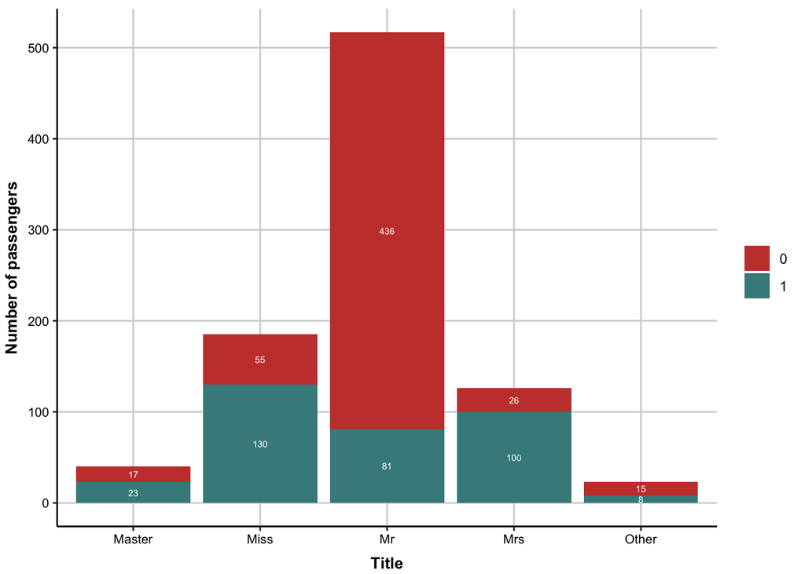

#### Family size

```r
# Combine siblings + parents/children
combined$FamilySize <- combined$SibSp + combined$Parch + 1
```

#### Family unit

```r
# Family Unit
# Extract Surnames
combined$Surname <- sapply(combined$Name,
                           FUN=function(x)
                           {strsplit(x, split='[,]')[[1]][1]})

# Combine with Family Size
combined$FamilyUnit <- paste(combined$Surname, "-", combined$FamilySize)

# How many unique families?
length(unique(combined$FamilyUnit))
```

```
## [1] 928
```

As expected there are many different family combinations … 928 infact! This is inpractical for predictive purposes, so let’s try and reduce the number of levels of this feature by combining ‘small’ and ‘medium’ sized families

```r
# Re-code families undr 2 as 'small families'
combined$FamilyUnit[combined$FamilySize <= 2] <- "Small"
combined$FamilyUnit[combined$FamilySize > 2 & combined$FamilySize <= 4] <- 'Medium'

# remove surname variable
combined$Surname <- NULL
```

Let’s examine the results of combining all family sizes under 2, and between 2 & 4 people:

| Var1 | Freq |
| --- | --- |
| Andersson - 7 | 9 |
| Asplund - 7 | 7 |
| Ford - 5 | 5 |
| Fortune - 6 | 6 |
| Goodwin - 8 | 8 |
| Hocking - 5 | 1 |
| Kink-Heilmann - 5 | 1 |
| Lefebre - 5 | 5 |
| Medium | 202 |
| Palsson - 5 | 5 |
| Panula - 6 | 6 |
| Rice - 6 | 6 |
| Richards - 6 | 1 |
| Ryerson - 5 | 5 |
| Sage - 11 | 11 |
| Skoog - 6 | 6 |
| Small | 1025 |

Much better!

#### Age Group

```r
# Age Group
combined$AgeGroup <- NA
combined$AgeGroup[combined$Age <= 12] <- "Child"
combined$AgeGroup[combined$Age > 12 & combined$Age <= 18] <- "Adolescent"
combined$AgeGroup[combined$Age > 18 & combined$Age <= 59] <- "Adult"
combined$AgeGroup[combined$Age >= 60] <- "Elderly Adult"
```

Below is a table summarising the percentage of surviving passengers by AgeGroup & Sex

| AgeGroup | Sex | Survived |
| --- | --- | --- |
| Adolescent | female | 75.00 |
| Adult | female | 77.54 |
| Child | female | 50.00 |
| Elderly Adult | female | 100.00 |
| Adolescent | male | 8.82 |
| Adult | male | 17.12 |
| Child | male | 50.00 |
| Elderly Adult | male | 13.64 |

#### Travel party size

Below we can approximate groups of passengers who travelled together, by extracting common string-names in the ticket, and common ticket numbers. This can be achieved by grouping passengers with commmon ticket details, aggregating the number of passengers with these ticket details, then re-combining this detail as a grouping variable with our original dataframe

```r
# Extracts out any letters before first space
# If no letters, no extraction
reg.ex2 <- ".*\\s|^[A-Z].*(?![0-9])$"
combined$TicketPre <- str_extract(combined$Ticket, reg.ex2)

# For tickets that do not begin with a character string ...
combined$TicketPre <- gsub("\\.|\\s|/", "", combined$TicketPre)
# Impute "_"
combined$TicketPre[is.na(combined$TicketPre)] <- "_"
## Convert to factor
combined$TicketPre <- factor(combined$TicketPre)

# Second half of ticket string
reg.ex3 <- "\\s[0-9]{1,}|^(?![A-Z]).*"
combined$TicketNumber <- str_extract(combined$Ticket, reg.ex3)
combined$TicketNumber[is.na(combined$TicketNumber)] <- "0"
combined$TicketNumber <- as.numeric(combined$TicketNumber)
combined$TicketNumber <- as.factor(combined$TicketNumber)

# Based upon common ticket numbers between passengers
# Calculate size of travel party
detach("package:plyr")
library(dplyr)
Ticket.Agg <- combined %>%
  group_by(TicketNumber) %>%
  summarise(Travel.Party.Size = n())

# Convert to dataframe
Ticket.Agg <- data.frame(Ticket.Agg)

Ticket.Agg$TicketNumber <- as.factor(Ticket.Agg$TicketNumber)

# Left Join
combined <- left_join(combined, Ticket.Agg, by = "TicketNumber")

# Seems highly unlikley this ticket is a travel party of 17
# Change to 1
combined$Travel.Party.Size[combined$TicketNumber== 2] = 1

combined$TicketPre <- NULL
combined$TicketNumber <- NULL
```

Let’s examine our breakdown of travel parties on the Titanic

| Var1 | Freq |
| --- | --- |
| 1 | 707 |
| 2 | 266 |
| 3 | 147 |
| 4 | 68 |
| 5 | 35 |
| 6 | 24 |
| 7 | 35 |
| 8 | 16 |
| 11 | 11 |

### Change variable types

```r
# As factor
combined$Title <- factor(combined$Title)
combined$AgeGroup <- factor(combined$AgeGroup)
combined$Pclass <- factor(combined$Pclass)
combined$FamilyUnit <- factor(combined$FamilyUnit)
# As numeric
combined$SibSp <- as.numeric(combined$SibSp)
combined$Parch <- as.numeric(combined$Parch)
combined$PassengerId <- as.numeric(combined$PassengerId)
```

### Feature Engineering

Finally, lets create two further binary predictors, by combining a number of our existing variables

Firstly, a factor variable delineating if a passenger is female, and in a travel part of more than two people

```r
# Female Group ***
combined$Female.Group <- as.factor(ifelse(combined$Sex == "female" &
                                          combined$Travel.Party.Size > 2, 1,0))
```

Below you can see 72% of females who travelled in groups survived

| Female.Group | Survived |
| --- | --- |
| 0 | 33.07 |
| 1 | 72.50 |

Secondly, a binary predictor of males who had the title ‘master’ (a proxi for being a child)

```r
# Male & Master
combined$Master.Male <- as.factor(ifelse(combined$Sex == "male" &
                                         combined$Title == "Master", 1,0))
```

In the dataset, 57% of young males survived, much better than the average survival rate of males

```r
# Contrary to most males on the ship, younger males were more likely to survive
MM <- aggregate(Survived ~ Master.Male,
          data = combined,
          FUN = function(x) {sum(x)/length(x)})

# multiply percent by 100
MM$Survived <- MM$Survived*100
# limit to 2 decimal places
MM <- MM %>%
  mutate_if(is.numeric, round, digits = 2)
# create table
kable(MM) %>%
  kable_styling(bootstrap_options = c("striped", "hover", "condensed", "responsive", font_size = 8))
```

| Master.Male | Survived |
| --- | --- |
| 0 | 37.49 |
| 1 | 57.50 |

## 2.Prediction

### Data set-up

Before we implement machine learning, we need to do some basic set-up

First, separate our data into test and train sets

```r
train <- combined[1:891,] # # survived data
test <- combined[892:1309,] # no survived data
```

Second, assess whether any data missing in our training set

```r
sapply(train, function(x) sum(is.na(x)))
```

```
##       PassengerId          Survived            Pclass              Name
##                 0                 0                 0                 0
##               Sex               Age             SibSp             Parch
##                 0                 0                 0                 0
##            Ticket              Fare             Cabin          Embarked
##                 0                 0               687                 0
##             Title        FamilySize        FamilyUnit          AgeGroup
##                 0                 0                 0                 0
## Travel.Party.Size      Female.Group       Master.Male
##                 0                 0                 0
```

Third, worth an eye-ball of correlations between predictors

```r
cor <- train
cor$PassengerId <- NULL
cor <- round(cor(cor[,unlist(lapply(cor,is.numeric))]),2)
lower <- cor
lower[lower.tri(cor, diag=TRUE)]<-""
lower <- as.data.frame(lower)
kable(lower) %>%
  kable_styling(bootstrap_options = c("striped", "hover", "condensed", "responsive", font_size = 8))
```

|  | Survived | Age | SibSp | Parch | Fare | FamilySize | Travel.Party.Size |
| --- | --- | --- | --- | --- | --- | --- | --- |
| Survived |  | -0.04 | -0.04 | 0.08 | 0.26 | 0.02 | 0.07 |
| Age |  |  | -0.32 | -0.21 | 0.11 | -0.33 | -0.28 |
| SibSp |  |  |  | 0.41 | 0.16 | 0.89 | 0.73 |
| Parch |  |  |  |  | 0.22 | 0.78 | 0.64 |
| Fare |  |  |  |  |  | 0.22 | 0.44 |
| FamilySize |  |  |  |  |  |  | 0.81 |
| Travel.Party.Size |  |  |  |  |  |  |  |

Not surprisingly, predictors “family size” and “travel party size” are highly correlated, and as such should probably not be included together in any model to avoid multicollinearity

Let’s ensure these results can be replicated:

```r
set.seed(2020)
```

The titanic data-set provides test (no survival status) and train (inc. survival status) data. In the absence of survival data in the test set, we have no means to compare our predicted values to actual values to evaluate model accuracy. Prediction accuracy is determined when submitting to Kaggle. As such, we can split the training set to get a (very) rough approximation of the models performance. With only a small number of cases, these results need to be interpreted with some trepidation

```r
train$Survived <- factor(train$Survived)

split = sample.split(train$Survived, SplitRatio = 0.8)
train.cv = subset(train, split == TRUE)
test.cv = subset(train, split == FALSE)
```

We are not ready to build & test our predictive model

### Model [1] Decision Tree

Decision Trees operate by splitting the independent variables in our model (sex, age etc), such that they result in the *largest* possible reduction in heterogeneity of the dependent variable (i.e. survival status). In other words, how do the variables most strongly distinguish survivors from non-surivors? If literally zero males aged over 50 survived, this would be a split in the tree. Hetereogeneity is estimated in three popular ways: Entropy, Gini Index and Classification Error

We will utilise the Recursive Partitioning And Regression Trees (rpart) package to implement this model, which splits the data via the *Gini Index*. The Gini Index measures the degree or probability of a particular variable being wrongly classified when it is randomly chosen

This [informative blog on the topic](https://eight2late.wordpress.com/2016/02/16/a-gentle-introduction-to-decision-trees-using-r/) provides a more detailed overview

A caveat is that the rpart algorithm works by making the *best possible choice/split at each particular stage*. This pays no mind to whether this decision remain optimal in future splits

#### Build Tree based model

The below snippet defines the dependent variable, independent variables & combines into a model

```r
# Outcome variable
(DV <- "Survived")

# Predictor variables Model [1]
(IVs <- c("Pclass", "Sex", "Age", "SibSp", "Parch", "Fare", "Embarked",
          "Title", "Master.Male", "Female.Group"))

# Create the formula string
(FMLA <- paste(DV, "~", paste(IVs, collapse = " + ")))

# Create recipe of formula
FMLA.Recipe <- recipe(Survived ~ Pclass + Sex + Age + SibSp +
                      Parch + Fare + Embarked +  Title + Master.Male +
                      Female.Group,
                      data = train.cv)
```

#### Cross Validation of Decision Tree

Utilising the split training data, let’s assess the accuracy of this model

First, create cross validation folds, specifying parameters

```r
folds = createMultiFolds(train.cv$Survived,
                         k = 10, # number of folds
                         times = 5) # number of partitions
```

Second, specify parameters for cross validation

```r
control <- trainControl(method = "repeatedcv",
                        index = folds,
                        number = 6,
                        search = "grid")
```

Third, create model from cross validation data

```r
# factorise
train.cv$Survived <- factor(train.cv$Survived)

tree.classifier.cv <- train(Survived ~ Pclass + Sex + Age + SibSp + Parch + Fare                             + Embarked + Title + Master.Male + Female.Group,
                       data = train.cv,
                       method = "rpart",
                       trControl = control)
```

Visualise cross validation tree

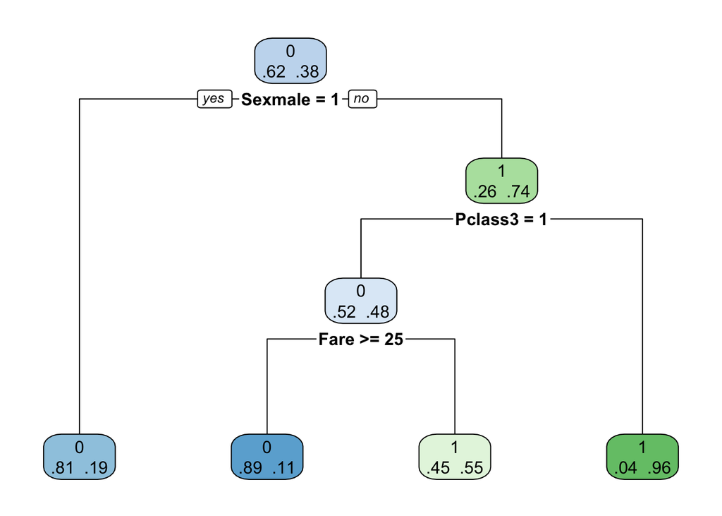

```r
rpart.plot(tree.classifier.cv$finalModel, extra=4)
```

Create list of predicted values

```r
# Predicting the Validation set results
y_predDT.CV = predict(tree.classifier.cv,
                      newdata = test.cv[,-which(names(test.cv) == "Survived")])
```

Create confusion matrix contrasting y actual versus y predicted values

```r
# Checking the prediction accuracy
table(test.cv$Survived, y_predDT.CV) # Confusion matrix
```

```
##    y_predDT.CV
##      0  1
##   0 98 12
##   1 19 49
```

Create error estimate (where known survival status mismatches with predicted survival status)

```r
# Check prediction accuracy
error <- mean(test.cv$Survived != y_predDT.CV) # Misclassification error
```

Calculate Accuracy as 1 minus error

```r
# 0.8258
paste('Accuracy =', round(1 - error, 4))
```

```
## [1] "Accuracy = 0.8258"
```

The result of cross validation is an accuracy estimate of 0.8258. Put another way, ~ 83% of passengers survival status was correctly predicted by the model

#### Final Model

We can repeat the previous steps on the full training set, ready to submit to Kaggle

Create model

```r
# Examine Decision Tree of model
tree <- rpart(FMLA,
              data = train,
              method = "class",
              control = rpart.control(minsplit = 20))
```

Plot the model

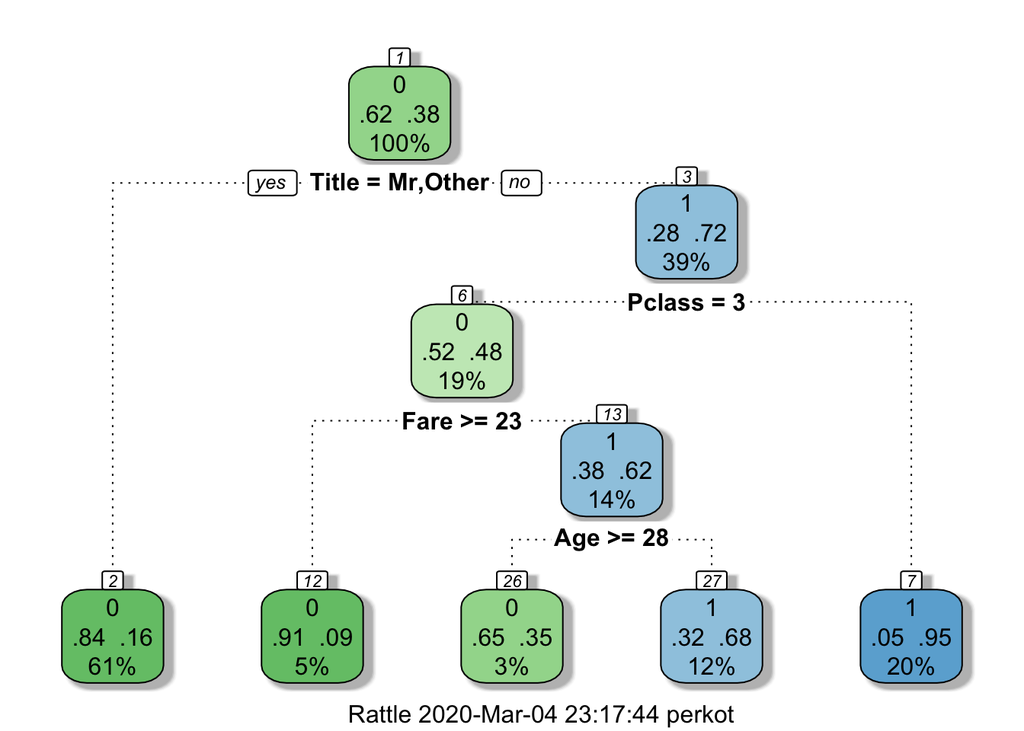

```r
fancyRpartPlot(tree)
```

Not surprisingly, using the full training dataset has produced a more nuanced splitting of variables. The most heterogeneous split occurred for surviving passengers where 95% survived when title != “mr” or “other”, and cabin class != third class

After reviewing this model, we can prepare the data for submission to Kaggle

```r
PredictionDT <- predict(tree,
                        test,
                        type = "class")

submitDT <- data.frame(PassengerId = test$PassengerId,
                       Survived = PredictionDT)

write.csv(submitDT, file = "TitanicDT.csv", row.names = FALSE)
```

This submission produces a Kaggle accuracy score of 0.7790. Not bad, but not great, & some way off the cross-validation result of ~ 0.82

Disparity between cross validated and submitted scores on the Titanic challenge is probably related to over-fitting of overly granular samples of data.

Consider the below limitation of Decision Tree’s articulated [in this blog](https://eight2late.wordpress.com/2016/02/16/a-gentle-introduction-to-decision-trees-using-r/) … to quote:

*An implication of their tendency to overfit data is that decision trees tend to be sensitive to relatively minor changes in the training datasets. Indeed, small differences can lead to radically different looking trees. Pruning addresses this to an extent, but does not resolve it completely. A better resolution is offered by the so-called ensemble methods*

The precise source of overfitting in the Titanic dataset is not limited to Decision Trees, & has been a common online discussion point. A discussion of this very issue & the role of variable *Sex* [can be found here](https://www.kaggle.com/c/titanic/discussion/53564)

All the same, ensemble methods better compensate for overfitting by averaging the result over *many trees*. With this in mind, let’s try and improve upon our model with a Random Forest model - one of the more popular ensemble applications of Decision Trees

### Model [2] Random Forest

Random Forests are an ensemble method that builds upon a standard Decision Tree by building *a forest* of many trees. This is achieved by random sampling of training data points when building trees, & random selection of subsets of variables when splitting nodes. More info [here](https://eight2late.wordpress.com/2016/09/20/a-gentle-introduction-to-random-forests-using-r/)

The use of multiple, random datasets to build trees is known as *bootstrap aggregating* (bagging). Each point in the dataset is equally likely to be chosen, & can appear multiple times in a subset. These bootstrap samples are then fed as training data to more Decision Tree’s

The ultimate result of the random forest is determined by “bagging” a majority vote from all the Decision Trees. This produces a primary statistical output, *out of bag error* which is equivalent to the number of correctly predicted rows from the out of bag sample

For the remainder of this kernel we will use the Random Forest package, which implements [Breiman’s random forest algorithm](https://www.rdocumentation.org/packages/randomForest/versions/4.6-14/topics/randomForest)

#### Tuning & cross validation of Random Forest parameters

When performing a Random Forest, there are many parameters that can be controlled that are summarised in [this medium article](https://medium.com/@ammubharatram/hyperparameter-tuning-of-random-forest-in-both-r-and-python-747b06b568db)

For this kernel’s purposes, we will focus on two:

**mtry**: the number of variables randomly sampled as candidates at each split. The default value is the square root of the number of variables (*p*) **ntree**: the number of trees to grow. Larger number of trees produce more stable models and covariate importance estimates. Too many trees can be surplus to requirements

For tuning, I have shamelessly lifted a custom algorithm developed by Jason Brownlee in his excellent article covering [tuning of random forest models](https://machinelearningmastery.com/tune-machine-learning-algorithms-in-r/)

```r
customRF <- list(type = "Classification",
                 library = "randomForest",
                 loop = NULL)

customRF$parameters <- data.frame(parameter = c("mtry", "ntree"),
                                  class = rep("numeric", 2),
                                  label = c("mtry", "ntree"))

customRF$grid <- function(x, y,
                          len = NULL,
                          search = "grid") {}

customRF$fit <- function(x, y,
                         wts,
                         param,
                         lev,
                         last,
                         weights,
                         classProbs, ...)
  {
  randomForest(x, y,
               mtry = param$mtry,
               ntree = param$ntree, ...)
  }

customRF$predict <- function(modelFit, newdata, preProc = NULL, submodels = NULL)
  predict(modelFit, newdata)

customRF$prob <- function(modelFit, newdata, preProc = NULL, submodels = NULL)
  predict(modelFit, newdata, type = "prob")

customRF$sort <- function(x) x[order(x[,1]),]

customRF$levels <- function(x) x$classes
```

Now specify parameters to assess … mtry between 1 & 5, & ntree between 1000 & 2500 in 500-tree increments. This step takes a little while to run so be patient :)

```r
# train model
control <- trainControl(method = "repeatedcv",
                        number = 10,
                        repeats = 3)
# specify tuning parameters for mtry & ntree
tunegrid <- expand.grid(.mtry = c(1:5),
                        .ntree = c(1000, 1500, 2000, 2500))
metric <- "Accuracy"

# to complete random forest, must be a factor
train.cv$Survived <- factor(train.cv$Survived)
# recipe for formula
rec <- recipe(Survived ~ Pclass + Sex + Age + SibSp + Parch + Fare + Embarked +
                Title + Master.Male + Female.Group,
              data = train.cv)

# this is ~ 10 minutes to run
custom <- train(rec,
                data = train.cv,
                method = customRF,
                metric = metric,
                tuneGrid = tunegrid,
                trControl = control)
```

Tabulate the results of the above tuning

```r
customdf <- as.data.frame(custom$results) %>%
  arrange(desc(Accuracy))

kable(customdf) %>%
  kable_styling(bootstrap_options = c("striped", "hover", "condensed", "responsive", font_size = 8))
```

| mtry | ntree | Accuracy | Kappa | AccuracySD | KappaSD |
| --- | --- | --- | --- | --- | --- |
| 3 | 2000 | 0.8298886 | 0.6304496 | 0.0461483 | 0.0996616 |
| 3 | 1500 | 0.8294258 | 0.6297415 | 0.0462017 | 0.1002602 |
| 3 | 2500 | 0.8280174 | 0.6257542 | 0.0457704 | 0.0991121 |
| 3 | 1000 | 0.8279913 | 0.6261842 | 0.0450050 | 0.0977295 |
| 4 | 2500 | 0.8261391 | 0.6249938 | 0.0459135 | 0.0978489 |
| 4 | 1500 | 0.8233682 | 0.6186207 | 0.0442640 | 0.0933326 |
| 4 | 1000 | 0.8233680 | 0.6189422 | 0.0475036 | 0.1016441 |
| 4 | 2000 | 0.8224290 | 0.6170452 | 0.0458702 | 0.0972688 |
| 5 | 1000 | 0.8200948 | 0.6131188 | 0.0474556 | 0.1001407 |
| 5 | 2000 | 0.8200818 | 0.6139800 | 0.0476674 | 0.0993387 |
| 2 | 1000 | 0.8195987 | 0.6049536 | 0.0447501 | 0.0983958 |
| 2 | 2000 | 0.8182033 | 0.6022705 | 0.0457221 | 0.1001713 |
| 5 | 1500 | 0.8181971 | 0.6096645 | 0.0467664 | 0.0968504 |
| 5 | 2500 | 0.8177472 | 0.6087947 | 0.0499870 | 0.1040020 |
| 2 | 2500 | 0.8177403 | 0.6012028 | 0.0456338 | 0.0999629 |
| 2 | 1500 | 0.8163319 | 0.5980909 | 0.0461188 | 0.1007812 |
| 1 | 1500 | 0.8102672 | 0.5848312 | 0.0474263 | 0.1036111 |
| 1 | 2000 | 0.8102476 | 0.5850393 | 0.0459158 | 0.1010933 |
| 1 | 1000 | 0.8098044 | 0.5840390 | 0.0446285 | 0.0988721 |
| 1 | 2500 | 0.8093282 | 0.5834521 | 0.0451043 | 0.0989064 |

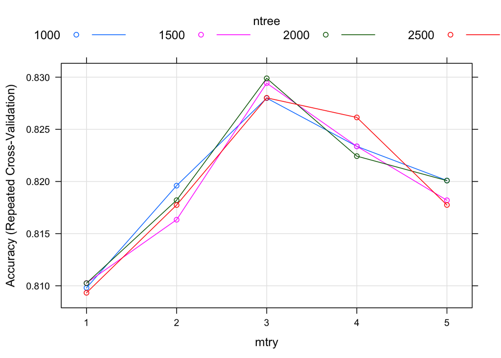

```r
plot(custom)
```

A number of noteworthy things …

Firstly, parameters set to ntree == 2000 & mtry == 3 yielded the highest accuracy of 0.8298

Kappa is a useful metric when a dataset is inbalanced (cf. [this link for definition of Kappa](https://stats.stackexchange.com/questions/82162/cohens-kappa-in-plain-english)). Although the titanic dataset isn’t as unbalanced as say credit-card fraud (where vast majority of transaction data will be non-fradulent) more people perished than survived.

Although there is no consensus guidelines on intepreting Kappa, a score in the range of 0.60 is considered fair to good

```r
RFCV <- randomForest(as.Formula(FMLA),
                    data = train.cv,
                    importance = TRUE,
                    index = folds,
                    do.trace = T,
                    mtry = 3,
                    ntree = 2000)
```

Let’s generate our predictions on the validation data

```r
# Predicting the Validation set results
y_predRF = predict(RFCV,
                   newdata = test.cv[,-which(names(test.cv)=="Survived")],
                   type='class')
```

Then create a confusion matrix that contrasts y actual with y predicted values from the test dataset

```r
# Checking the prediction accuracy
table(test.cv$Survived, y_predRF) # Confusion matrix
```

```
##    y_predRF
##      0  1
##   0 98 12
##   1 14 54
```

Create error estimate (where known survival status mismatches with predicted survival status), then subtract from 1 for overall error score

```r
# Check prediction accuracy
error <- mean(test.cv$Survived != y_predDT.CV) # Misclassification error

paste('Accuracy',round(1-error,4))
```

[output not shown]

Let’s repeat these steps on our full training dataset, & prepare for submission to Kaggle

#### Final Model

```r
train$Survived <- factor(train$Survived)
RF <- randomForest(as.Formula(FMLA),
                     data = train,
                     importance = TRUE,
                     do.trace = T,
                     mtry = 3,
                     ntree = 2000)
```

```r
print(RF)
```

```
##
## Call:
##  randomForest(formula = as.Formula(FMLA), data = train, importance = TRUE,      do.trace = T, mtry = 3, ntree = 2000)
##                Type of random forest: classification
##                      Number of trees: 2000
## No. of variables tried at each split: 3
##
##         OOB estimate of  error rate: 15.82%
## Confusion matrix:
##     0   1 class.error
## 0 505  44  0.08014572
## 1  97 245  0.28362573
```

Let’s now plot variable importance from this model:

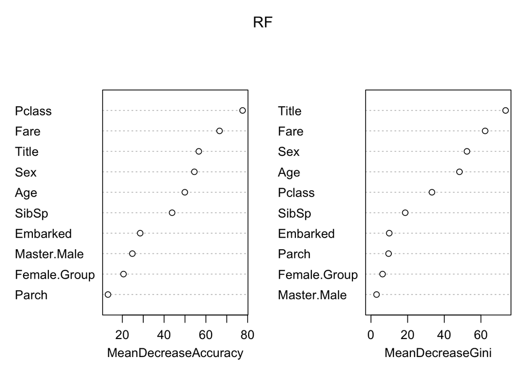

```r
varImpPlot(RF)
```

This plot provides two metrics

Firstly, **Mean Decrease Accuracy** which assesses the observed reduction in model performance without each variable. In other words, a big decrease in model accuracy would be anticipated for strong predictors

Secondly, **Mean Decrease GINI** measures how pure the nodes are at the end of the tree. It is similarly an assessment to evaluate model performance if each variable is taken out. A high score indicates higher variable importance

In this model, Fare, Title, Class & Sex appear to be among the strongest predictors

Let’s now plot error rates

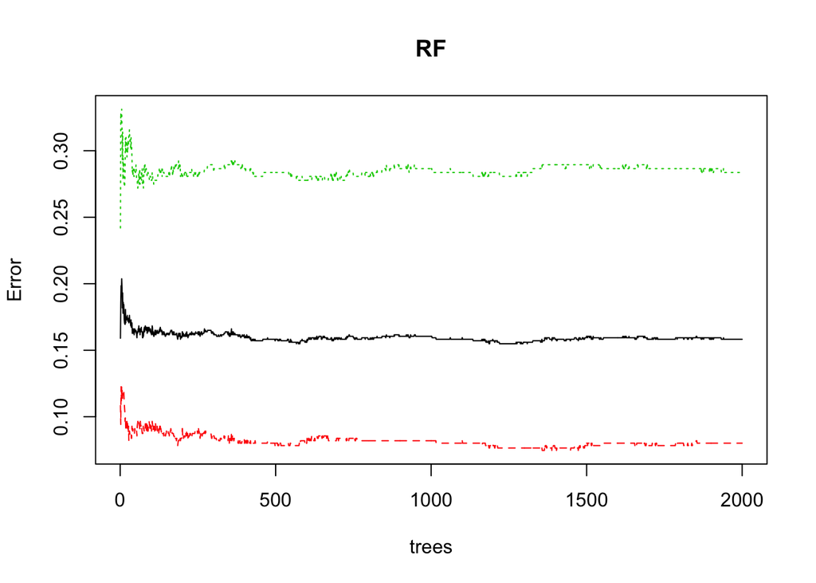

```r
plot(RF)
```

The error plot is useful to evaluate model performance against the number of trees. The coloured lines represent our predicted classes of survived (green) or perished (red), whilst the black represents out of bag samples . It clearly shows a steep reduction in error over the first 100 or so trees which stabilises with more smaller improvements in error rate observed up to 2000 trees

Finally, let’s complete a Receiver Operating Characteristics (ROC) plot

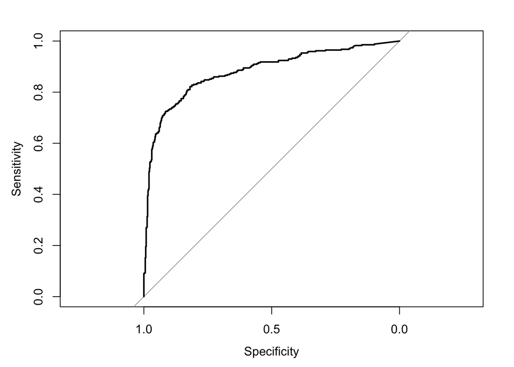

```r
rf.roc <- roc(train$Survived,RF$votes[,2])
plot(rf.roc)
```

```r
auc(rf.roc)
```

```
## Area under the curve: 0.8806
```

The ROC curve plots true-positive rates (y axis, sensitivity) against false positive rates (x axis, specificity)

When two distributions overlap, (i.e. variance of surived & perished passengers), we introduce type 1 and type 2 error. Depending upon the threshold, such error rates can be minimised or maximised. An AUC score of 0.88 indicates an ~ 88% chance this model will be able to distinguish between survivors and non-survivors. More information on ROC plots can be found [here](https://towardsdatascience.com/understanding-auc-roc-curve-68b2303cc9c5)

Once satisfied with our model and its output, we can bind our predicted survival values to the Passenger IDs of the test set, & convert to a .csv file to export

```r
conf <- RF$confusion
RF$confusion[, 'class.error']
```

```
##          0          1
## 0.08014572 0.28362573
```

```r
PredictionRF <- predict(RF, test)
submitRF <- data.frame(PassengerId = test$PassengerId,
                           SurvivedRF = PredictionRF)
write.csv(submitRF, file = "TitanicRF.csv", row.names = FALSE)
```

Submitting this file to Kaggle resulted in an overall score of **0.80382**